# Project 1: Object Detection on Traffic Light Dataset

#### Maximum Points: 100

In this project, the goal is to train an object detection model to detect traffic light color using the dataset provided in this notebook. You can use any framework or model, for example YOLO or RT-DETR and inference techniques like SAHI for better detection of small objects. The focus is on creating an accurate and efficient solution for identifying traffic light color.

**The dataset is provided in YOLO format. However, you are free to convert it to any format of your choice according to the library that you are using**

**The dataset contains a total of 5 classes:**

```
0: 'Green',
1: 'off',
2: 'red',
3: 'wait_on',
4: 'yellow'
```

## Your Tasks

- Train an object detection model.
- Perform inference on the given video file.
- Share your inference video in an accessible format, such as uploading it to YouTube or providing a shared drive link.
- Provide a video or writeup link explaining your code and approach.

**Alternatively, you can also upload your writeup document to the online lab.**

**Mark Distribution**:

### No.

### Criteria

### Marks

### 1.

### Dataset Visualization

### 15

### 2.

### mAP50-95 >= 48%

### 70

### 3.

### Inference on Test Video

### 10

### 4.

### Writeup/Video Explanation

### 5

```python
import sys, subprocess

commands = [
    [sys.executable, "-m", "pip", "install", "torch", "--index-url", "https://download.pytorch.org/whl/cpu"],
    [sys.executable, "-m", "pip", "install", "ultralytics", "opencv-python", "pandas", "numpy", "tqdm", "nbformat", "matplotlib", "pyyaml"],
    [sys.executable, "-m", "pip", "install", "sahi", "supervision"],
]
for cmd in commands:
    print("Running:", " ".join(cmd))
    subprocess.run(cmd, check=False)

import random
from pathlib import Path
from ultralytics import YOLO


import yaml


import cv2
import matplotlib.pyplot as plt

import pandas as pd
```

```
Running: /usr/bin/python3 -m pip install torch --index-url https://download.pytorch.org/whl/cpu
Running: /usr/bin/python3 -m pip install ultralytics opencv-python pandas numpy tqdm nbformat matplotlib pyyaml
Running: /usr/bin/python3 -m pip install sahi supervision
     ━━━━━━━━━━━━━━━━━━━━━━━━━━━━━━━━━━━━━━━ 207.2/207.2 KB 1.1 MB/s eta 0:00:00
  Using cached opencv_python-4.11.0.86-cp37-abi3-manylinux_2_17_x86_64.manylinux2014_x86_64.whl (63.0 MB)
  Attempting uninstall: opencv-python
    Found existing installation: opencv-python 4.12.0.88
    Uninstalling opencv-python-4.12.0.88:
      Successfully uninstalled opencv-python-4.12.0.88
```

```python
DATA_ROOT = Path("Small Traffic Light.v1i.yolov11")
EPOCHS = 120
IMGSZ = 960
BATCH = 16
DEVICE = "0"
SEED = 42
USE_SAHI = True
VIDEO_PATH = Path("inference_traffic_light_video.mp4")
WEIGHTS_PATH = Path("runs/best.pt")
MODEL_PATH = Path("yolov8l.pt")
CLASS_NAMES = ["green", "off", "red", "wait_on", "yellow"]
```

```python
TRAIN_IMAGES_DIR = DATA_ROOT / "train" / "images"
VAL_IMAGES_DIR = DATA_ROOT / "valid" / "images"
if not VAL_IMAGES_DIR.exists():
    alt = DATA_ROOT / "val" / "images"
    if alt.exists():
        VAL_IMAGES_DIR = alt
if not TRAIN_IMAGES_DIR.exists():
    raise FileNotFoundError(f"Missing training images in {TRAIN_IMAGES_DIR}")
if not VAL_IMAGES_DIR.exists():
    raise FileNotFoundError(f"Missing validation images in {VAL_IMAGES_DIR}")
```

```python
cfg = {
    "path": str(DATA_ROOT.resolve()),
    "train": str(TRAIN_IMAGES_DIR.resolve()),
    "val": str(VAL_IMAGES_DIR.resolve()),
    "names": dict(enumerate(CLASS_NAMES)),
}
out_dir = Path("runs/data_configs");
out_dir.mkdir(parents=True, exist_ok=True)
```

```python
DATA_YAML_PATH = out_dir / f"traffic_light_{DATA_ROOT.name.replace(' ', '_')}.yaml"
content = yaml.safe_dump(cfg, sort_keys=False)
if not DATA_YAML_PATH.exists() or DATA_YAML_PATH.read_text() != content:
    DATA_YAML_PATH.write_text(content)

print(
    f"Data YAML: {DATA_YAML_PATH}\n"
    f"Train images: {TRAIN_IMAGES_DIR}\n"
    f"Val images: {VAL_IMAGES_DIR}\n"
    f"Classes: {CLASS_NAMES}"
)
```

```
Data YAML: runs/data_configs/traffic_light_Small_Traffic_Light.v1i.yolov11.yaml
Train images: Small Traffic Light.v1i.yolov11/train/images
Val images: Small Traffic Light.v1i.yolov11/valid/images
Classes: ['green', 'off', 'red', 'wait_on', 'yellow']
```

```python
def yolo_to_xyxy(row, w, h):
    cls, xc, yc, bw, bh = row
    x1 = max(0, int((xc - bw / 2) * w))
    y1 = max(0, int((yc - bh / 2) * h))
    x2 = min(w - 1, int((xc + bw / 2) * w))
    y2 = min(h - 1, int((yc + bh / 2) * h))
    return int(cls), x1, y1, x2, y2

def preview_samples(n=3):
    imgs = [p for ext in ("*.jpg", "*.png") for p in sorted(TRAIN_IMAGES_DIR.glob(ext))]
    if not imgs:
        print("No training images found for preview.");
        return

    picks = random.sample(imgs, min(n, len(imgs)))
    fig, axes = plt.subplots(1, len(picks), figsize=(5*len(picks), 5))
    axes = [axes] if len(picks) == 1 else axes

    for ax, img_path in zip(axes, picks):
        img = cv2.cvtColor(cv2.imread(str(img_path)), cv2.COLOR_BGR2RGB)
        h, w = img.shape[:2]

        lbl = img_path.parent.parent / "labels" / f"{img_path.stem}.txt"
        if lbl.exists():
            for line in lbl.read_text().splitlines():
                cls, x1, y1, x2, y2 = yolo_to_xyxy([float(x) for x in line.split()], w, h)
                cv2.rectangle(img, (x1, y1), (x2, y2), (0,255,0), 2)
                ax.text(x1, max(12, y1+12), CLASS_NAMES[int(cls)], color="yellow",
                        fontsize=9, bbox=dict(facecolor="black", alpha=0.5, pad=1))

        ax.imshow(img);
        ax.axis("off")

    plt.tight_layout();
    plt.show()
```

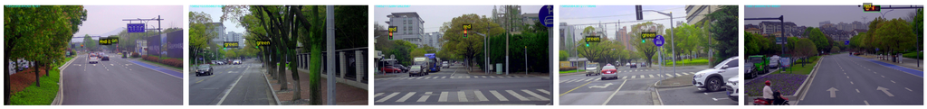

```python
preview_samples(n=5)
```

```python
yolo_cmd = [
    "yolo", "detect", "train",
    f"data={DATA_ROOT}/data.yaml",
    f"model={MODEL_PATH}",
    f"epochs={EPOCHS}",
    f"imgsz={IMGSZ}",
    f"batch={BATCH}",
    f"device={DEVICE}",
    f"seed={SEED}",
    "patience=20"
]

print("Executing:", " ".join(yolo_cmd))
result = subprocess.run(yolo_cmd, check=False)
```

[output not shown]

[output cut: 458 more lines]

```
Optimizer stripped from /home/cv-sse/Pictures/opencv-project1/runs/detect/train3/weights/best.pt, 87.7MB

Validating /home/cv-sse/Pictures/opencv-project1/runs/detect/train3/weights/best.pt...
Ultralytics 8.3.200 🚀 Python-3.10.12 torch-2.8.0+cu128 CUDA:0 (NVIDIA GeForce RTX 4090, 24072MiB)
Model summary (fused): 112 layers, 43,610,463 parameters, 0 gradients, 164.8 GFLOPs
                 Class     Images  Instances      Box(P          R      mAP50  mAP50-95): 100% ━━━━━━━━━━━━ 12/12 7.2it/s 1.7s0.1s
                   all        367        741      0.967      0.746      0.865        0.5
                 green        193        243      0.936      0.909      0.934      0.608
                   off          2          2          1          0      0.505      0.353
                   red        257        373      0.956      0.935       0.96      0.604
               wait_on         97         97       0.94       0.97      0.964      0.487
                yellow         24         26          1      0.917      0.962       0.45
Speed: 0.1ms preprocess, 3.5ms inference, 0.0ms loss, 0.3ms postprocess per image
Results saved to /home/cv-sse/Pictures/opencv-project1/runs/detect/train3
💡 Learn more at https://docs.ultralytics.com/modes/train
```

```python
df = pd.read_csv("runs/detect/train3/results.csv")
best = df.loc[df["metrics/mAP50-95(B)"].idxmax()]
best
```

```
epoch                     69.000000
time                    1457.790000
train/box_loss             1.195190
train/cls_loss             0.573750
train/dfl_loss             0.886930
metrics/precision(B)       0.966510
metrics/recall(B)          0.745870
metrics/mAP50(B)           0.864940
metrics/mAP50-95(B)        0.499660
val/box_loss               1.321920
val/cls_loss               0.613700
val/dfl_loss               0.951620
lr/pg0                     0.000488
lr/pg1                     0.000488
lr/pg2                     0.000488
Name: 68, dtype: float64
```

```python
model = YOLO("runs/detect/train3/weights/best.pt")
results = model.predict(
    source="inference_traffic_light_video.mp4",
    conf=0.25,
    iou=0.5,
    save=True,
    project="runs/predict",
    name="video_infer",
    exist_ok=True,
    device=0
)
print("Done! Results saved in:", results[0].save_dir)
```

[output not shown]

[output cut: 413 more lines]

[output not shown]

```python
from IPython.display import HTML

HTML("""
<video
    controls
    src="https://www.dropbox.com/home?preview=inference_traffic_light_video.avi"
    width="640">
</video>
""")
```

[video not shown]

### You can access the viedo from the following link:

https://www.dropbox.com/scl/fi/wi48hs3m1mwv7u787qlhu/inference_traffic_light_video.avi?rlkey=uqyau80jyx889eato6mt69o1q&st=xdkhovj0&dl=0

## Project Overview

Built and trained a YOLO model to detect five traffic light states: **green**, **red**, **yellow**, **off**, and **wait_on**.

## Training the Model

Training was using Ultralytics YOLO:

yolo detect train data=Small Traffic Light.v1i.yolov11/data.yaml model=yolov8l.pt epochs=120 imgsz=960 batch=16 device=0 patience=20

### Best model results

- metrics/precision(B) 0.966510
- metrics/recall(B) 0.745870
- metrics/mAP50(B) 0.864940
- metrics/mAP50-95(B) 0.499660

## Video Inference

The trained weights (`best.pt`) are used for inference on a test video.

- https://www.dropbox.com/scl/fi/wi48hs3m1mwv7u787qlhu/inference_traffic_light_video.avi?rlkey=uqyau80jyx889eato6mt69o1q&st=xdkhovj0&dl=0

The trained model achieved strong performance in detecting traffic light colors.